# Внешний курс. Блок 3: Криптография на практике

Основы информационной безопасности

Петрова А.А.

Российский университет дружбы народов, Москва, Россия

16 мая 2025

# Информация

## Докладчик

- Петрова Алевтина Александровна
- НКАбд-04-23
- Российский университет дружбы народов

## Цель

Пройти третий блок курса “Основы кибербезопасности”

## Задание

Выполнение контрольных заданий третьего блока внешнего курса “Основы Кибербезопасности”

## Вопрос 4.1.1

Для ответа на вопрос используется определение асимметричного шифрования с двумя ключами

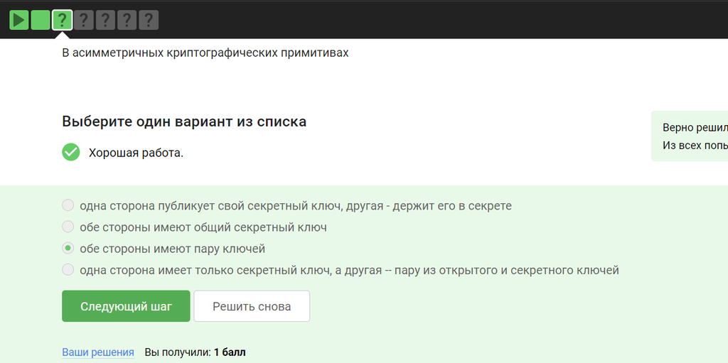

## Вопрос 4.1.2

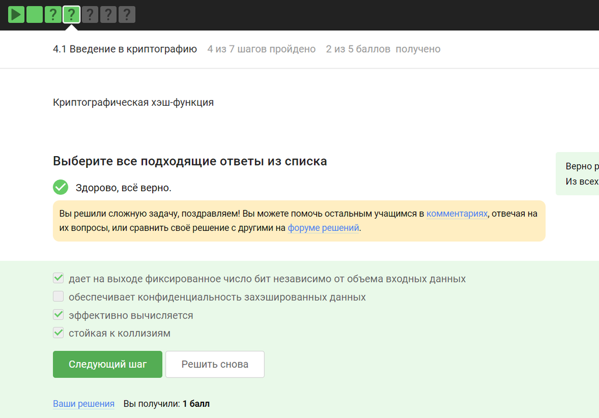

## Вопрос 4.1.3

Отмечены алгоритмы цифровой подписи

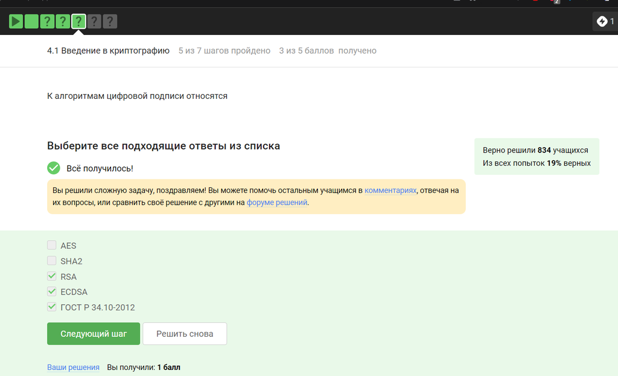

## Вопрос 4.1.4

В информационной безопасности аутентификация сообщения или аутентификация источника данных-это свойство, которое гарантирует, что сообщение не было изменено во время передачи (целостность данных) и что принимающая сторона может проверить источник сообщения

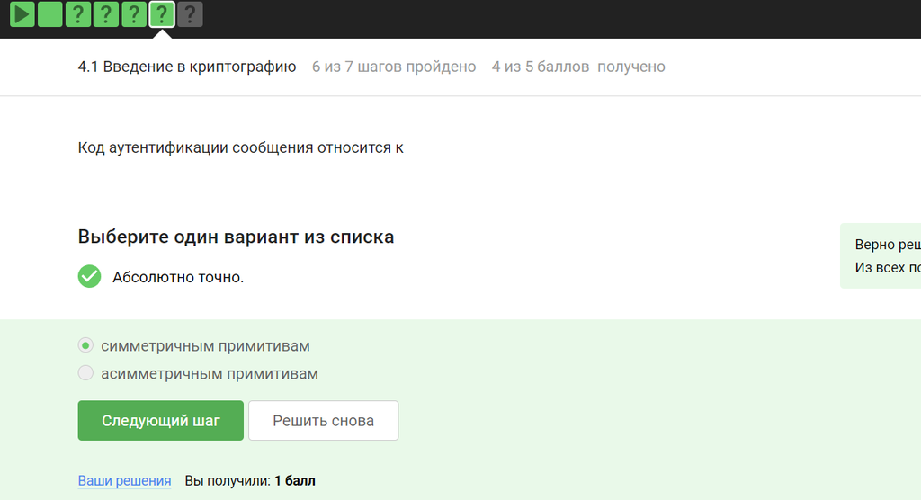

## Вопрос 4.1.5

Определение обмена ключами Диффи-Хэллмана.

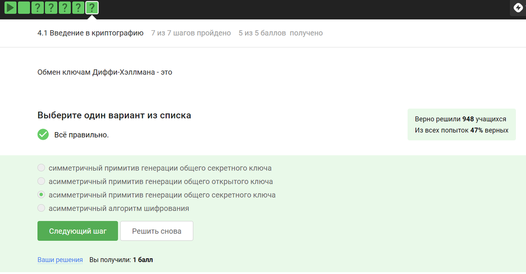

## Вопрос 4.2.1

По определению цифровой подписи протокол ЭЦП относится к протоколам с публичным ключом

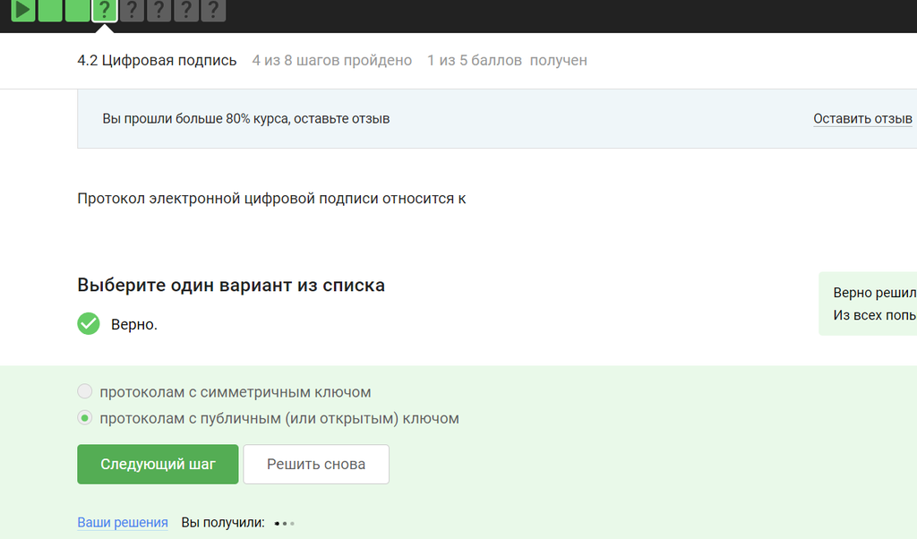

## Вопрос 4.2.2

Алгоритм верификации электронной подписи состоит в следующем. На первом этапе получатель сообщения строит собственный вариант хэш-функции подписанного документа. На втором этапе происходит расшифровка хэш-функции, содержащейся в сообщении с помощью открытого ключа отправителя. На третьем этапе производится сравнение двух хэш-функций. Их совпадение гарантирует одновременно подлинность содержимого документа и его авторства

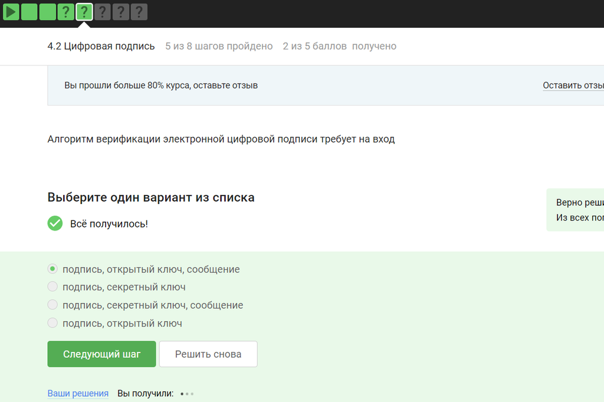

## Вопрос 4.2.3

Электронная подпись обеспечивает все указанное, кроме конфиденциальности

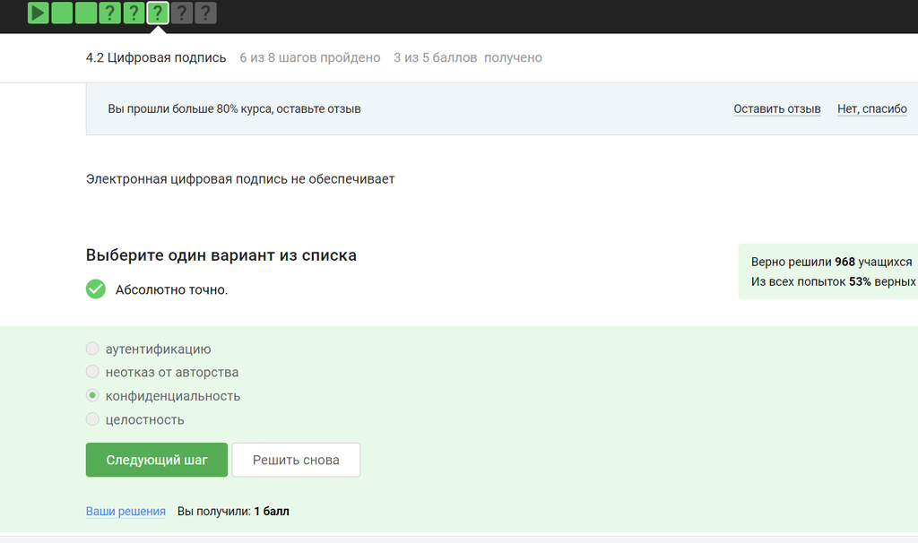

## Вопрос 4.2.4

Для отправки налоговой отчетности в ФНС используется усиленная квалифицированная электронная подпись

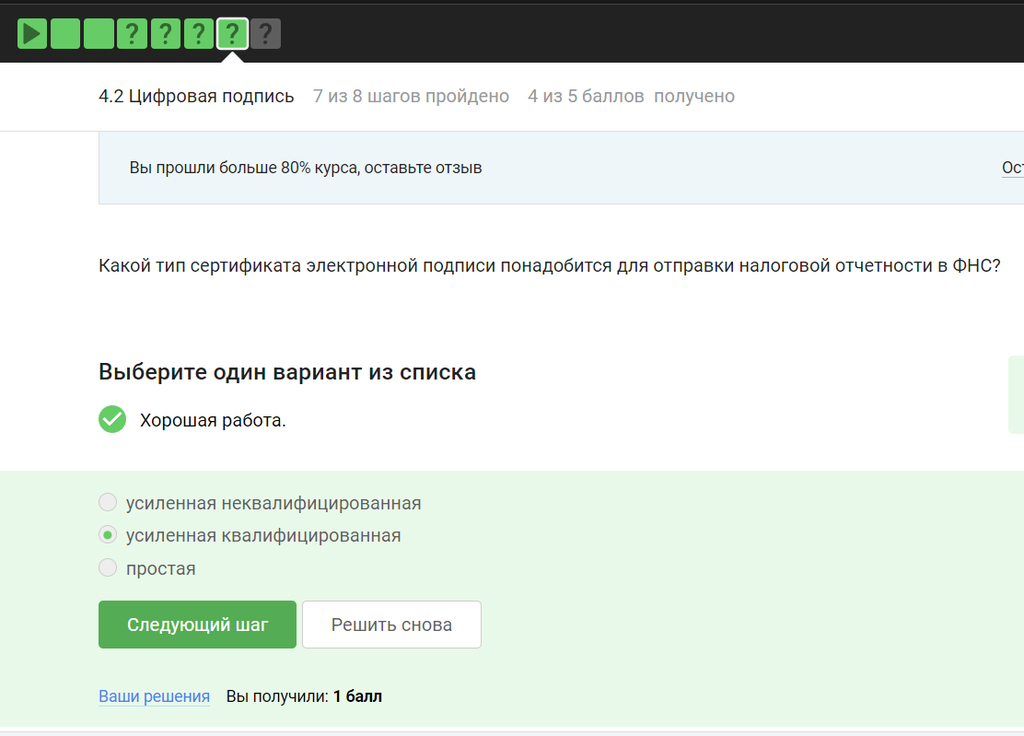

## Вопрос 4.2.5

Верный ответ указан на изображении

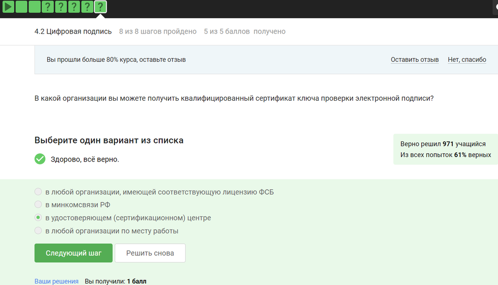

## Вопрос 4.3.1

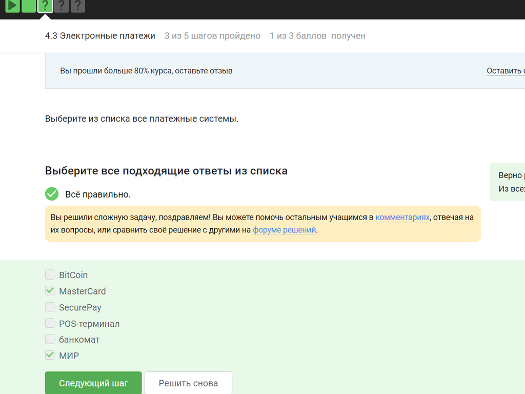

## Вопрос 4.3.2

Верный ответ на изображении

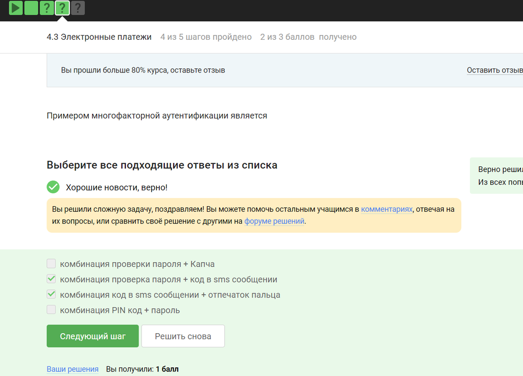

## Вопрос 4.3.3

При онлайн платежах используется многофакторная аутентификация

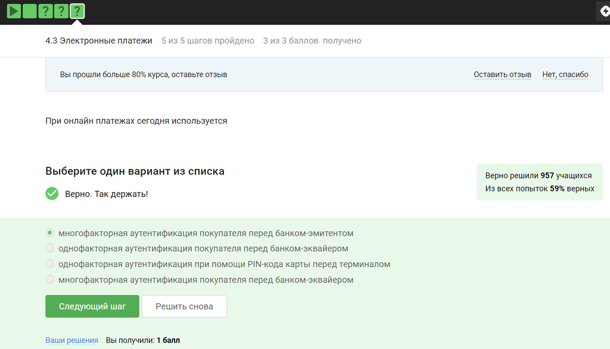

## Вопрос 4.4.1

Proof-of-Work, или PoW, (доказательство выполнения работы) — это алгоритм достижения консенсуса в блокчейне; он используется для подтверждения транзакций и создания новых блоков. С помощью PoW майнеры конкурируют друг с другом за завершение транзакций в сети и за вознаграждение. Пользователи сети отправляют друг другу цифровые токены, после чего все транзакции собираются в блоки и записываются в распределенный реестр, то есть в блокчейн.

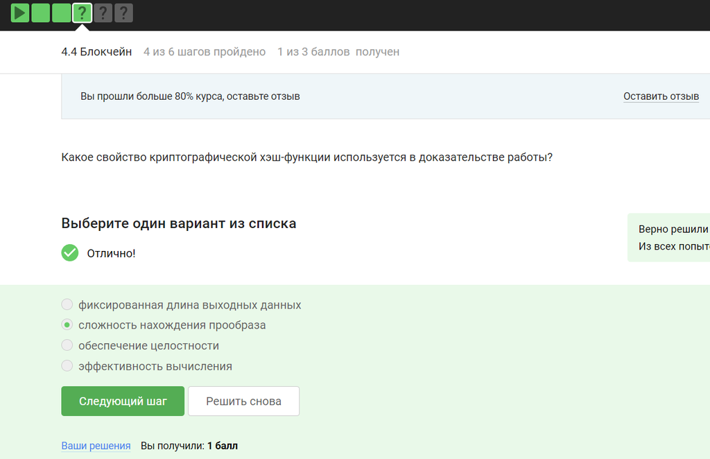

## Вопрос 4.4.2

Консенсус блокчейна — это процедура, в ходе которой участники сети достигают согласия о текущем состоянии данных в сети. Благодаря этому алгоритмы консенсуса устанавливают надежность и доверие к самоу сети.

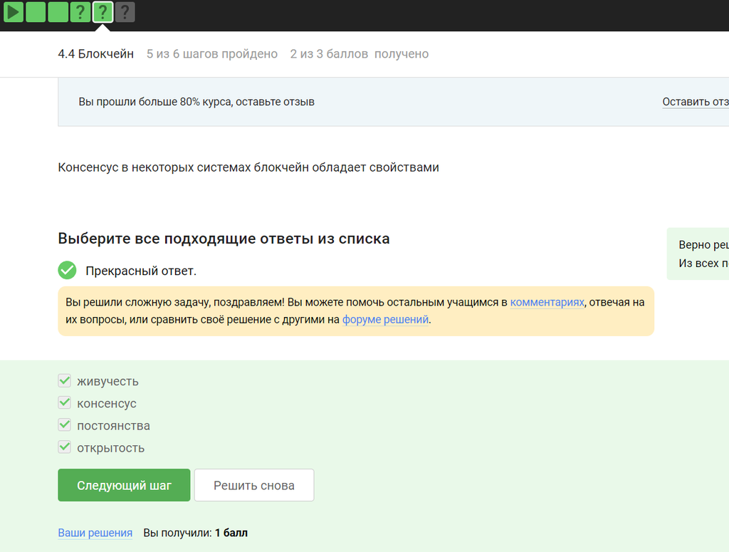

## Вопрос 4.4.3

Ответ - цифровая подпись

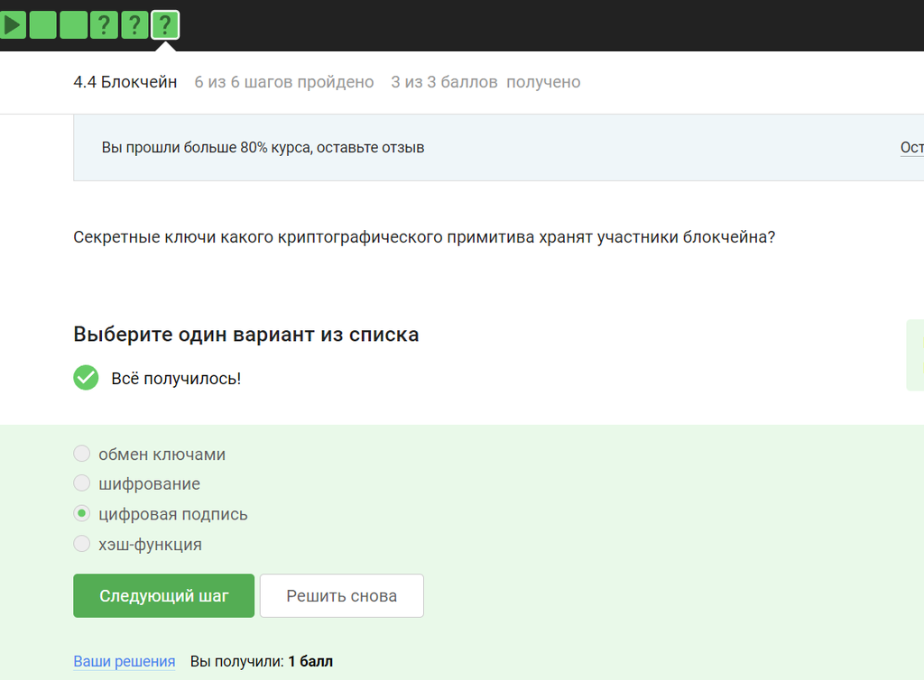

## Вывод

Третий блок пройден успешно

[figure not shown]